## Note: Because it is a demo code, datasets will be chose only in lesser dimensions; It no way means that real data will be like this.

## It is purely to understand the internals of the algorithms; It is your responsibilty how you will make use of these.

# Demo code to explain ROC curve

- Assume
- 1. We have class labels for a binary calssificatin problem of 15 data points i.e Actualvalues.
- 1. A model gave predictions in the form of probabilities. i.e predcitions

```python
Actualvalues=[0,0,1,0,1,0,1,0,0,1,1,1,1,0,0]
predictions=[0.6,0.5,0.4,0.4,0.6,0.4,0.7,0.4,0.8,0.3,0.65,0.7,0.25,0.35,0.5]
```

```python
print(len(Actualvalues))
print(len(predictions))
```

```
15
15
```

# ROC curve

- Let us recall how an ROC cuve is plotted (fpr vs tpr)
- It will calcualte fpr and tpr values for different threshold of probabilities
- Range of threshold is 0 to 1
- Eg: if Threshold=0.4; All the values less than 0.4 will be zero remaning are 1.-from this we can calcualte tpr and fpr

## Let us define threshold of values;

- Becuse it is a demo we restrict oursleves to few values

```python
Thresholds=[0.1,0.2,0.3,0.4,0.5,0.6,0.7,0.8,0.9]
```

## Prediction for threshold 0.5

- It is the default value

```python
newpredictions=[]
for i in range(0,15):
    if(predictions[i]>=0.5):
        newpredictions.append(1)
    else:
        newpredictions.append(0)
```

```python
print(newpredictions)
print(Actualvalues)
```

```
[1, 1, 0, 0, 1, 0, 1, 0, 1, 0, 1, 1, 0, 0, 1]
[0, 0, 1, 0, 1, 0, 1, 0, 0, 1, 1, 1, 1, 0, 0]
```

- The above code is to calcualate is for a threshold values
- With the knowledge of the above code- we can calculate the list of predictions for every other threshold 0.1,0.2,...

## Write the code as stated above

- Define an empty list predictions_threshold
- Use another for loop to iterate the previous code with different threshold values

  '''predictions_threshold=[]

  ```
   for i in range( , ):
       newpredictions=[]
       for j in range(0,15):
           if():
               your code here
           else:
               your code here
    predictions_threshold.append(newpredictions)
  ```

  '''

```python
# define an empty list predictions_threshold
# use another for loop to iterate the previous code with different threshold values
predictions_threshold=[]
for i in range(0,9):
    newpredictions=[]
    j=0
    for j in range(0,15):
        #print(i,j)
        if(predictions[j]>=Thresholds[i]):
            newpredictions.append(1)
        else:
            newpredictions.append(0)
    predictions_threshold.append(newpredictions)
```

```python
len(predictions_threshold)
```

```
9
```

## Calcualte the following;

  ''' for i in range( , )

  ```
        if( )
         write your code
        if( )
         write your code
         ...
         ...
         ...
  ```

  '''

```python
# Use a for loop to iteratate through a Actualvalues and predictions list
#and if to compare the values
def counts(Actualvalues,predictions_threshold):
    tp=0
    fp=0
    tn=0
    fn=0

    for i in range(0,15):
    ### BEGIN SOLUTION
        if(Actualvalues[i]==1 and predictions_threshold[0][i]==1):
            tp=tp+1
        if(Actualvalues[i]==1 and predictions_threshold[0][i]==0):
            fn=fn+1
        if(Actualvalues[i]==0 and predictions_threshold[0][i]==1):
            fp=fp+1
        if(Actualvalues[i]==0 and predictions_threshold[0][i]==0):
            tn=tn+1
    ### END SOLUTION
    return tp,fp,tn,fn
```

```python
sum(counts(Actualvalues,predictions_threshold))
```

```
15
```

```python
### BEGIN HIDDEN TEST
assert (sum(counts(Actualvalues,predictions_threshold))==15)
### END HIDDEN TEST
```

```python
tp,fp,tn,fn=counts(Actualvalues,predictions_threshold)
```

- In the previous code we have seen calcuating tp,fp,tn,fn for one prediction list
- Repeat it for all the prediction values

## Write the code to get the list of all as stated above and calcualte tpr,fpr,tnr,ppr

- True Positive Ratio(Recall)=tp/(tp+fn)
- False Positive Ratio=fp/(tn+fp)
- True Negative Ratio(Specificity)=tn/(tn+fp)
- Predicted Positive Ratio(Precision)=tp/(tp+fp)
- Write the below function
- '''def ratios(Actualvalues,predictions_threshold):

  ```
     define empty lists tpr,fpr,tnr,ppr
  ```

- Write a for loop to iterate with different threshold values;
- Note: to come out of divided by zero error, you have to think a littile bit.

  ```
     for j in range( , ):
        Code from previous cell including looop
     .....
     .....
     .....
     ..... write your code
     .....
     .....
  return tpr,fpr,tnr,ppr '''
  ```

```python
# define lists tpr,fpr,tnr,ppr
def ratios(Actualvalues,predictions_threshold):
    ### BEGIN HIDDEN SOLUTION
    tpr=[]
    fpr=[]
    tnr=[]
    ppr=[]
# Write a for loop to iterate with different threshold values;
# Note: to come out of divided by zero error, you have to think a littile bit.

    for j in range(0,9):
        tp=0
        fp=0
        tn=0
        fn=0
        for i in range(0,15):
            if(Actualvalues[i]==1 and predictions_threshold[j][i]==1):
                tp=tp+1
            if(Actualvalues[i]==1 and predictions_threshold[j][i]==0):
                fn=fn+1
            if(Actualvalues[i]==0 and predictions_threshold[j][i]==1):
                fp=fp+1
            if(Actualvalues[i]==0 and predictions_threshold[j][i]==0):
                tn=tn+1
        if(tp==0):
            tpr.append(0)
            ppr.append(0)
        else:
            tpr.append(tp/(tp+fn))
            ppr.append(tp/(tp+fp))

        if(tn==0):
            tnr.append(0)
            fpr.append(1)
        else:
            tnr.append(tn/(tn+fp))
            fpr.append(fp/(fp+tn))
    ### END HIDDEN SOLUTION
    return tpr,fpr,tnr,ppr
```

```python
tpr,fpr,tnr,ppr=ratios(Actualvalues,predictions_threshold)
### START HIDDEN TEST
assert any(tnr+fpr)
```

- In the above code you have calculated required tpr and fpr for all thresholds

## Plot the tpr and fpr values

- Scatterplot between fpr and tpr
- Add a line plot x=[0,1], y=[0,1]

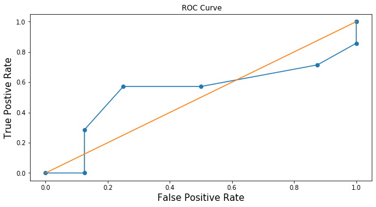

```python
from matplotlib import pyplot as plt
plt.figure(figsize=(10,5))
plt.plot(fpr,tpr,'-o')
#plt.text(Thresholds)
plt.plot([0,1],[0,1])
plt.xlabel('False Positive Rate',fontsize=15)
plt.ylabel('True Postive Rate',fontsize=15)
plt.title(' ROC Curve')
plt.show()
```

- from the above plot we can only see the set of tpr-fpr for each threshold

```python
print(fpr)
print(tpr)
```

```
[1, 1, 1, 0.875, 0.5, 0.25, 0.125, 0.125, 0.0]
[1.0, 1.0, 0.8571428571428571, 0.7142857142857143, 0.5714285714285714, 0.5714285714285714, 0.2857142857142857, 0, 0]
```

# Let us Go and see How actually ROC Curve from the Library for same data points

- Observe the output carefully and make a sense out of it. Let us not worry too much about auc calcualtion; get the intution of how roc curve is plotted.

```python
# Compute ROC curve and ROC area for each class
from sklearn.metrics import roc_auc_score,roc_curve,auc
fpr1 = dict()
tpr1 = dict()
roc_auc = dict()
fpr1, tpr1, _ = roc_curve(Actualvalues,predictions)
roc_auc = auc(fpr1,tpr1)
```

```python
roc_auc
```

```
0.5357142857142857
```

```python
from sklearn.metrics import roc_auc_score,roc_curve,auc
print(Actualvalues)
print(predictions)
fpr1, tpr1, _ = roc_curve(Actualvalues,predictions)
```

```
[0, 0, 1, 0, 1, 0, 1, 0, 0, 1, 1, 1, 1, 0, 0]
[0.6, 0.5, 0.4, 0.4, 0.6, 0.4, 0.7, 0.4, 0.8, 0.3, 0.65, 0.7, 0.25, 0.35, 0.5]
```

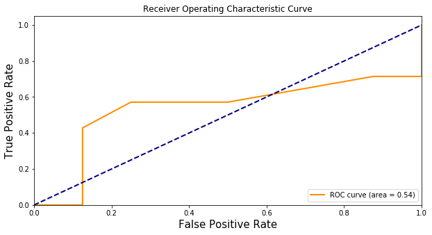

```python
plt.figure(figsize=(10,5))
plt.plot(fpr1,tpr1, color='darkorange',lw=2, label='ROC curve (area = %0.2f)' % roc_auc)
plt.plot([0, 1], [0, 1], color='navy', lw=2, linestyle='--')
plt.xlim([0.0, 1.0])
plt.ylim([0.0, 1.05])
plt.xlabel('False Positive Rate',fontsize=15)
plt.ylabel('True Positive Rate',fontsize=15)
plt.title('Receiver Operating Characteristic Curve')
plt.legend(loc="lower right")
plt.show()
```

```python
auc(fpr1,tpr1)
```

```
0.5357142857142857
```

```python
auc(fpr,tpr)
```

```
0.5357142857142857
```